# Bayesian Predictive Accuracy

# Simulation: Normal posteriors

$$y | \theta \sim N(\theta, 1)$$

One observed value, $y = 4$

```r
y <- 4
```

$$\hat{\theta}_1 \sim N(0, 1), \qquad \hat{\theta}_2 \sim N(10, 3), \qquad \hat{\theta}_3 \sim N(10, 6)$$

I might be wrong, but since we have the posteriors for $\theta$, we would have to translate this into a predictive distribution for $y$. It won’t change much but I think this is how they defined it in Gelman.

```r
set.seed(30071999)
theta_1 <- rnorm(10000, mean = 0, sd = 1)
theta_2 <- rnorm(10000, mean = 10, sd = 3)
theta_3 <- rnorm(10000, mean = 10, sd = 6)

pred_1 <- rnorm(10000, mean = theta_1, sd = 1)
pred_2 <- rnorm(10000, mean = theta_2, sd = 1)
pred_3 <- rnorm(10000, mean = theta_3, sd = 1)
```

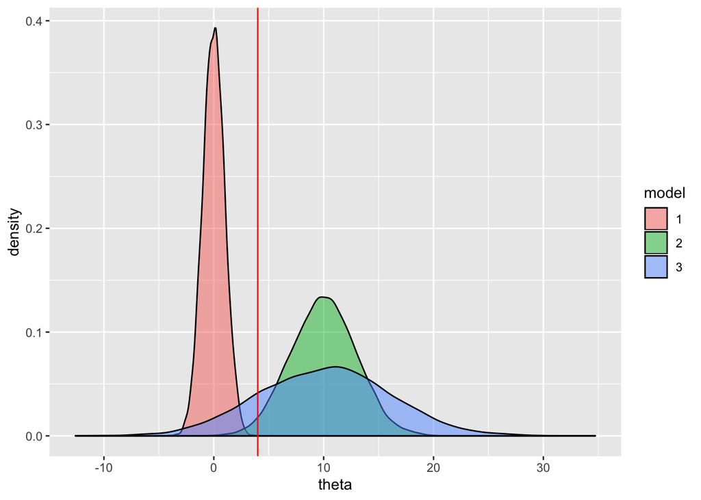

```r
distributions <- data.frame(theta = c(theta_1,theta_2,theta_3), model = rep(c("1","2","3"), each = 10000),
                            y_pred = c(pred_1,pred_2,pred_3))

# Plot posterior distributions for \theta ~ N(?, ?)
distributions %>%
  ggplot() +
  geom_density(mapping = aes(x = theta, fill = model), alpha = 0.5) +
  geom_vline(xintercept = 4, color = "red")
```

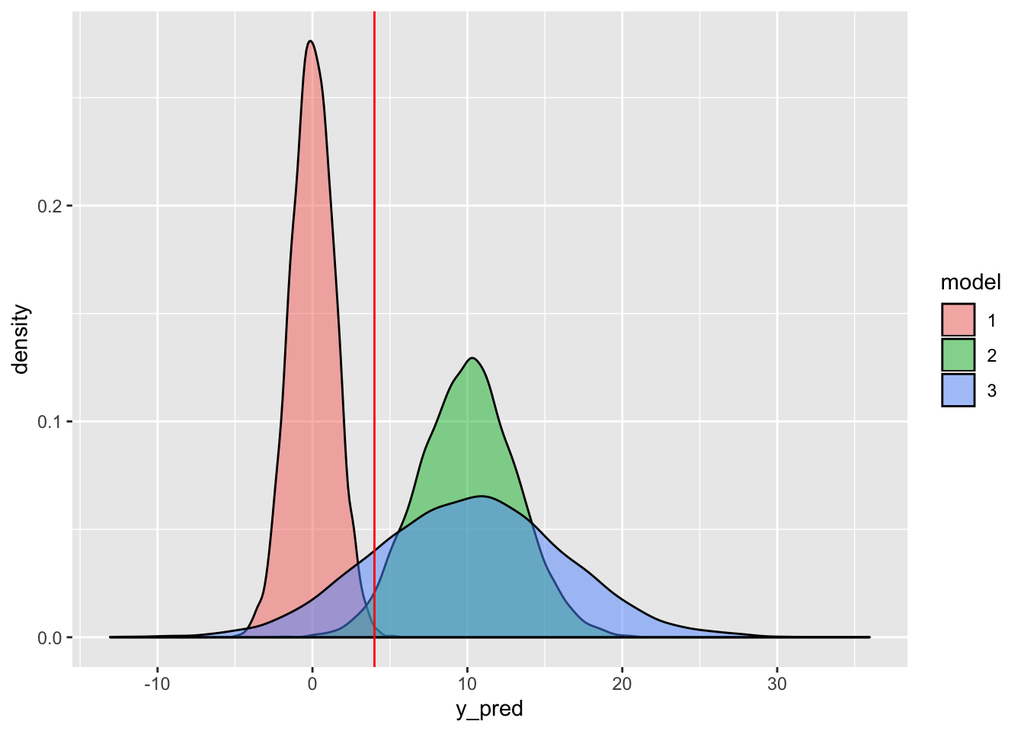

```r
# Plot predictive distributions for y ~ N(\theta, 1)
distributions %>%
  ggplot() +
  geom_density(mapping = aes(x = y_pred, fill = model), alpha = 0.5) +
  geom_vline(xintercept = 4, color = "red")
```

## Mean squared error & weighted mean squared error

Unweighted MSE makes model 1 look best.

```r
# MSE for models 1, 2, & 3
(y - mean(pred_1))^2
```

```
## [1] 15.9835
```

```r
(y - mean(pred_2))^2
```

```
## [1] 35.94032
```

```r
(y - mean(pred_3))^2
```

```
## [1] 36.74256
```

Weighted MSE makes model 3 look best

Son: We’re looking at a posterior mean estimator and the squared number of standard deviations the observation is away. Thinking about it for a bit, the “best” rated model can completely disregard any form of bias as long as it keeps variance high. For example:

$$\hat{y}_4 \sim N(100, 100^2)$$

```r
# Weighted MSE for models 1, 2, & 3
(y - mean(pred_1))^2 / var(pred_1)
```

```
## [1] 8.032175
```

```r
(y - mean(pred_2))^2 / var(pred_2)
```

```
## [1] 3.631524
```

```r
(y - mean(pred_3))^2 / var(pred_3)
```

```
## [1] 0.985224
```

```r
# Model that disregards bias in posterior estimator is vague
theta_4 <- rnorm(10000, mean = 100, sd = 100)
pred_4 <- rnorm(10000, mean = theta_4, sd = 1)
(y - mean(pred_4))^2 / var(pred_4)
```

```
## [1] 0.932451
```

## Ala gelman?

Calculate $p(y|\theta)$ at each $\theta$ in simulation. I don’t have $p(y|\theta)$. Predictive distribution of $y$ drawn from $p(y|\theta)$ from fake $p(\theta)$.

Son: I interpret LPD in section 2.3 of Gelman as simply a model’s fit with future data. I measure these below for all 3 of our models. I was a little confused but I think this is because we assume a posterior mean as our prediction in this section. I don’t think you have to make up $\theta$ as we have 3 models for it already. The tricky part is (1) where the true distribution of future data must be known to determine the ELPD from our model, this seems all theoretical however. We can’t quite find ELPD it seems because we can’t know what the true $\tilde{y}$ but this would kinda be the expected fit of a model to new data.

Model 3 also seems to do the best when I translate it to just a log predictive density at the point $y = 4$. This makes sense since model 3 has the most density at that point. My intuition for this measure is that we simply want to make sure our observations land within some dense zone as you explained before.

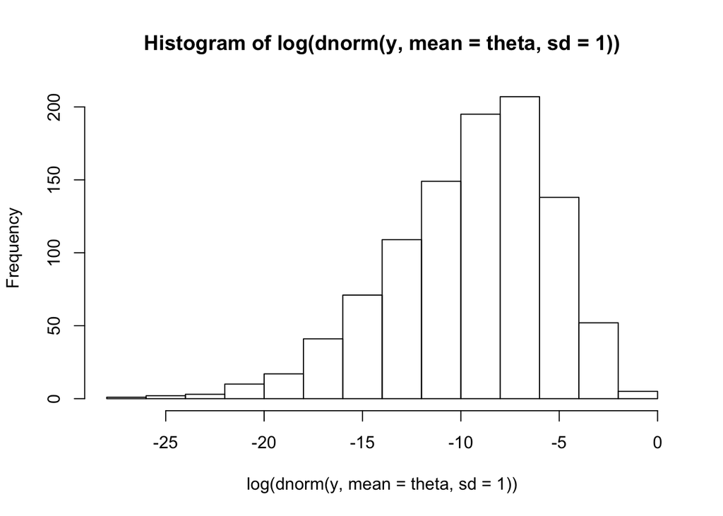

```r
# draw theta
theta <- rnorm(n = 1000, mean = 0, sd = 1)

# like plot on p20 of gelman
hist(log(dnorm(y, mean = theta, sd = 1)))
```

```r
# log predictive density
# log the posterior mean | density of the future y observation distribution | this depends on \theta as the RV
log(mean(dnorm(x = y, mean = theta_1, sd = 1))) # model 1
```

```
## [1] -5.293742
```

```r
log(mean(dnorm(x = y, mean = theta_2, sd = 1))) # model 2
```

```
## [1] -3.883589
```

```r
log(mean(dnorm(x = y, mean = theta_3, sd = 1))) # model 3
```

```
## [1] -3.190414
```

## Using median absolute deviation?!?

https://en.wikipedia.org/wiki/Median_absolute_deviation

(y - posterior median) / MAD

NOTE: When squared, I think this is similar to the weighted mse

Son: So we’re looking at the number of mean absolute deviations our observed $y$ is away from the median of $\hat{y}_n$. This makes sense to me! I always thought about how much information you could get from data by looking at just a mean and a median. I also removed the ‘abs()’ after squaring and also normalized $MAD$ to $1$. So would this be considered a weighted absolute/squared deviation from the median? Clearly this only parallels very well with the mean measures in a mean = median case.

```r
# R scales the MAD.  Use constant = 1 to get raw
mad(c(1,2,3))
```

```
## [1] 1.4826
```

```r
mad(c(1,2,3), constant = 1)
```

```
## [1] 1
```

Model 3 is best by this measure

```r
# Comparing to median
abs(y - median(pred_1)) / mad(pred_1, constant = 1)
```

```
## [1] 4.168629
```

```r
abs(y - median(pred_2)) / mad(pred_2, constant = 1)
```

```
## [1] 2.865406
```

```r
abs(y - median(pred_3)) / mad(pred_3, constant = 1)
```

```
## [1] 1.492806
```

```r
# Squared = similar to weighted MSE
((y - median(pred_1)) / mad(pred_1, constant = 1))^2
```

```
## [1] 17.37747
```

```r
((y - median(pred_2)) / mad(pred_2, constant = 1))^2
```

```
## [1] 8.210552
```

```r
((y - median(pred_3)) / mad(pred_3, constant = 1))^2
```

```
## [1] 2.22847
```

## DIC (maybe not right)

the smaller the DIC the better

Model 1 is best by DIC. Perhaps because of the assumption that the data are generated by N(theta, 1).

TO DO: TRY WITH asymmetric and multimodal distributions!!!!!

```r
# RETURN: DIC measure for some future data and posterior predictive distribution based on theta model and prediction rule
# y: future data
# theta_model: posterior theta we choose based on past y
# bayes_predict: rule to choose theta_hat_bayesian from our posterior theta. Posterior mean by default
# WARNING: We assume a predictive function y|theta ~ N(theta, 1); can further generalize

dic_fncn <- function(y, theta_post, bayes_predict = mean) {
    theta_bayes = bayes_predict(theta_post)

    pdic <- 2 * ( dnorm(y, mean = theta_bayes, sd = 1, log = TRUE) - mean(dnorm(y, mean = theta_post, sd = 1, log = TRUE)) )
    -2*dnorm(y, mean = theta_bayes, sd = 1, log = TRUE) + 2*pdic
}

dic_fncn(4, theta_post = theta_1, bayes_predict = mean)
```

```
## [1] 19.90583
```

```r
dic_fncn(4, theta_post = theta_2, bayes_predict = mean)
```

```
## [1] 55.5359
```

```r
dic_fncn(4, theta_post = theta_3, bayes_predict = mean)
```

```
## [1] 111.021
```

```r
dic_fncn(4, theta_post = theta_1, bayes_predict = median)
```

```
## [1] 19.96466
```

```r
dic_fncn(4, theta_post = theta_2, bayes_predict = median)
```

```
## [1] 55.38904
```

```r
dic_fncn(4, theta_post = theta_3, bayes_predict = median)
```

```
## [1] 109.6099
```

```r
dic_fncn(4, theta_post = theta_1, bayes_predict = Mode)
```

```
## [1] 21.22015
```

```r
dic_fncn(4, theta_post = theta_2, bayes_predict = Mode)
```

```
## [1] 57.34837
```

```r
dic_fncn(4, theta_post = theta_3, bayes_predict = Mode)
```

```
## [1] 97.3166
```

### An Intuitive Explanation of DIC

1. Choose some estimator based on the posterior distribution of our parameter of interest (posterior mean, median, MAP, etc.). Call this $\hat{\theta}_{\text{Bayes}}$.
2. Calculate how well a new data point fits into the posterior predictive distribution given $\hat{\theta}_{\text{Bayes}}$. This “goodness-of-fit” or predictive accuracy measure for a distribution can be expressed as a log-score.
3. Effective number of parameters is another way to gauge the “general complexity” of a model. This is expressed as the goodness-of-fit under $\hat{\theta}_{\text{Bayes}}$ compared to the EXPECTED predictive accuracy under any other $\hat{\theta}$ from the posterior $\theta$ distribution.

Intuitively, we can think of this is a one-to-one mapping of every $\theta$ within our posterior to an accuracy under $y$ and build a distribution out of it. The key is to consider how much accuracy we get out of the model for a single estimate $\hat{\theta}_{\text{Bayes}}$ (say the posterior mean) vs how much accuracy we get out of every $\theta$ in the posterior model.

$$\begin{align*}
DIC &= -2 \log p(y | \hat{\theta}_{\text{Bayes}}) + 2p_{\text{DIC}} \\
&= \underbrace{-2 \log p(y | \hat{\theta}_{\text{Bayes}})}_\text{accuracy under one $\hat{\theta}$} + \underbrace{4 \left(\log p(y | \hat{\theta}_{\text{Bayes}}) - \E\left[ \log p(y | \theta) \right] \right)}_{\text{accuracy difference between one $\theta$ and overall distribution of $\theta$}}
\end{align*}$$
I don’t think you can think of DIC strictly in terms of the posterior summary stats for $\theta$. I would start out by finding the predictive accuracy distribution under the log rule. This would give us the distribution of how well $y$ fits in with our predictions over all possible $\theta$ choices. I also add lines to indicate the predictive accuracy under the posterior mean $\hat{\theta}_{\text{Bayes}}$.

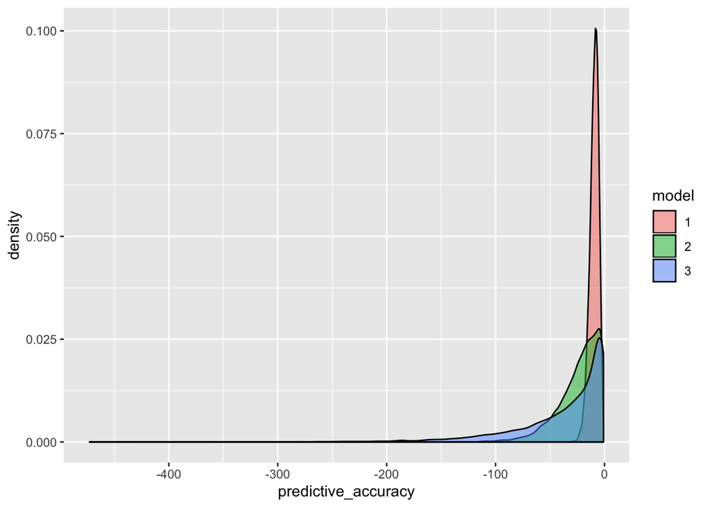

```r
log_acc_dist_1 <- dnorm(y, mean = theta_1, sd = 1, log = TRUE)
log_acc_dist_2<- dnorm(y, mean = theta_2, sd = 1, log = TRUE)
log_acc_dist_3 <- dnorm(y, mean = theta_3, sd = 1, log = TRUE)

log_acc_distributions <- data.frame(predictive_accuracy = c(log_acc_dist_1,log_acc_dist_2,log_acc_dist_3), model = rep(c("1","2","3"), each = 10000))

ggplot(data = log_acc_distributions) +
  geom_density(mapping = aes(x = predictive_accuracy, fill = model), alpha = 0.5)
```

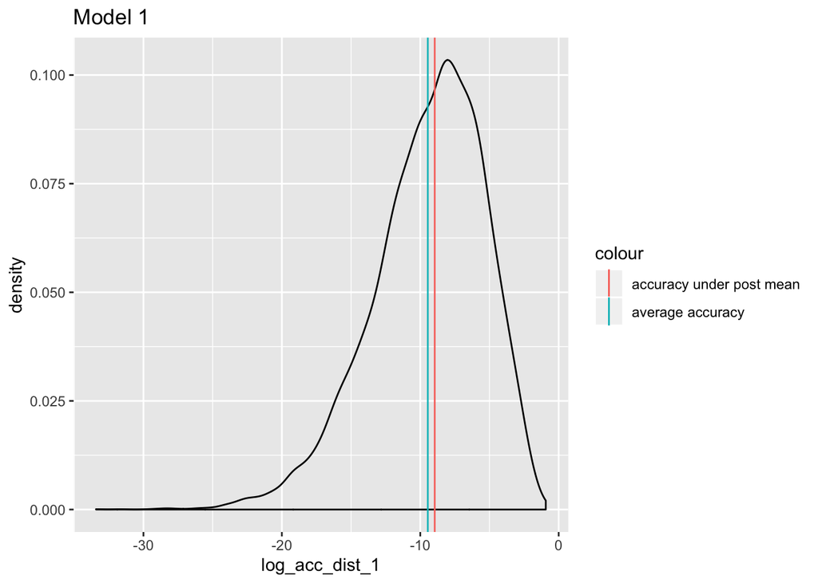

```r
ggplot() +
  geom_density(mapping = aes(x = log_acc_dist_1), alpha = 0.5) +
  geom_vline(mapping = aes(xintercept = mean(log_acc_dist_1), color = "average accuracy")) +
  geom_vline(mapping = aes(xintercept = dnorm(y, mean = mean(theta_1), sd = 1, log = TRUE), color = "accuracy under post mean")) +
  ggtitle("Model 1")
```

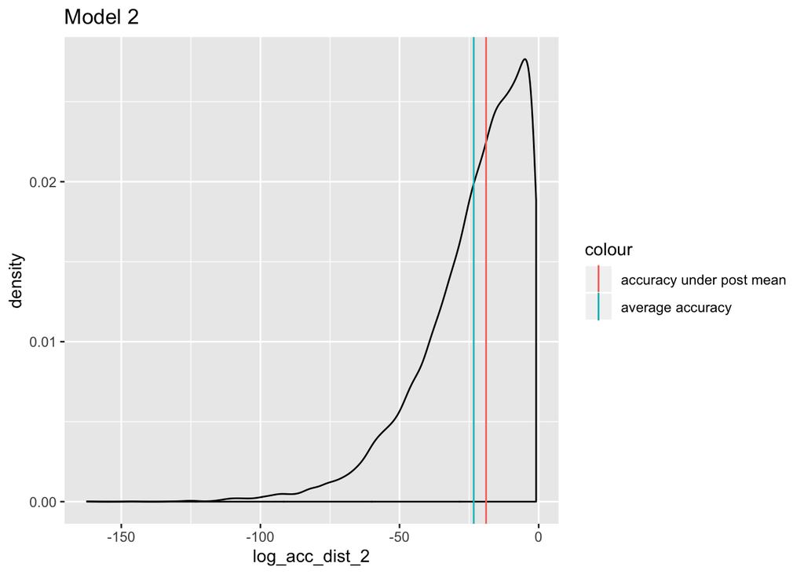

```r
ggplot() +
  geom_density(mapping = aes(x = log_acc_dist_2), alpha = 0.5) +
  geom_vline(mapping = aes(xintercept = mean(log_acc_dist_2), color = "average accuracy")) +
  geom_vline(mapping = aes(xintercept = dnorm(y, mean = mean(theta_2), sd = 1, log = TRUE), color = "accuracy under post mean")) +
  ggtitle("Model 2")
```

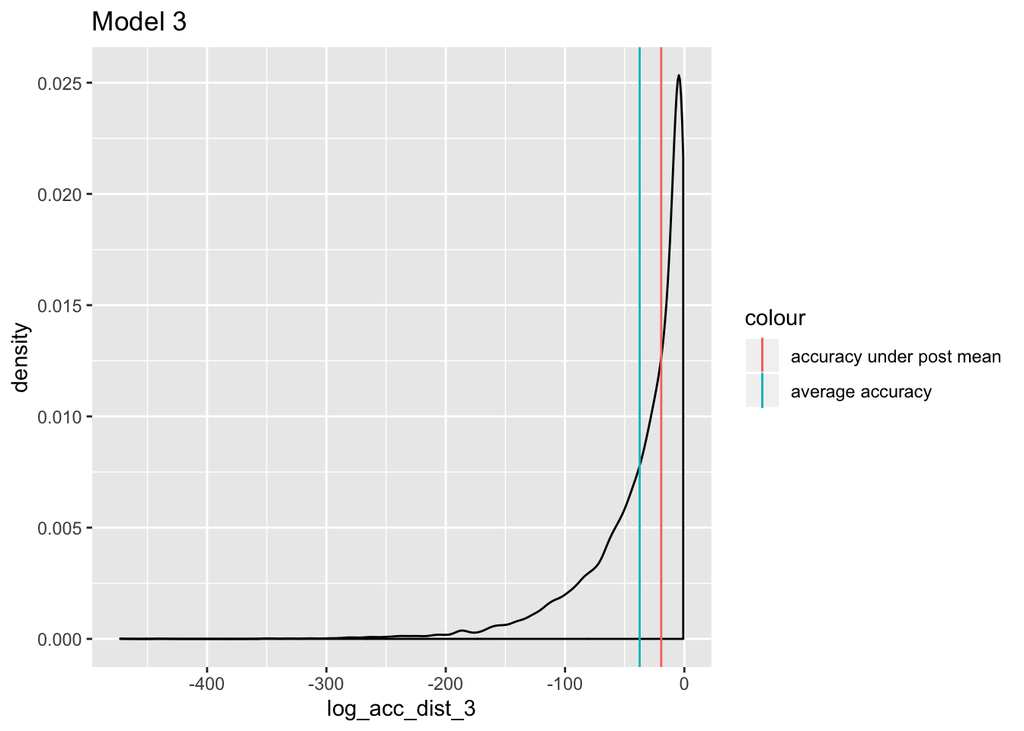

```r
ggplot() +
  geom_density(mapping = aes(x = log_acc_dist_3), alpha = 0.5) +
  geom_vline(mapping = aes(xintercept = mean(log_acc_dist_3), color = "average accuracy")) +
  geom_vline(mapping = aes(xintercept = dnorm(y, mean = mean(theta_3), sd = 1, log = TRUE), color = "accuracy under post mean")) +
  ggtitle("Model 3")
```

```r
# This is consistent with http://kylehardman.com/BlogPosts/View/6
pred <- pred_1
L = log(dnorm(4,mean(pred)))
S = length(pred)
llSum = 0
for (s in 1:S) {
theta_s = pred[s]
llSum = llSum + log(dnorm(4,theta_s))
}
P = 2 * (L - (1 / S * llSum))
DIC = -2 * (L - P)
```

# Simulation: Asymmetric Distributions

I consider 3 Gamma posterior predictive distributions:

$$Y_1 \sim \text{Gamma}(1, 1), \quad Y_2 \sim \text{Gamma}(13, 2), \quad Y_3 \sim \text{Gamma}(7, 1)$$

Suppose we observe a point $Y = 3$. I’m not quite sure if I chose my parameters to line up well with our symmetric arguments. I chose to line up the modes of $Y_2$ and $Y_3$ rather than the means.

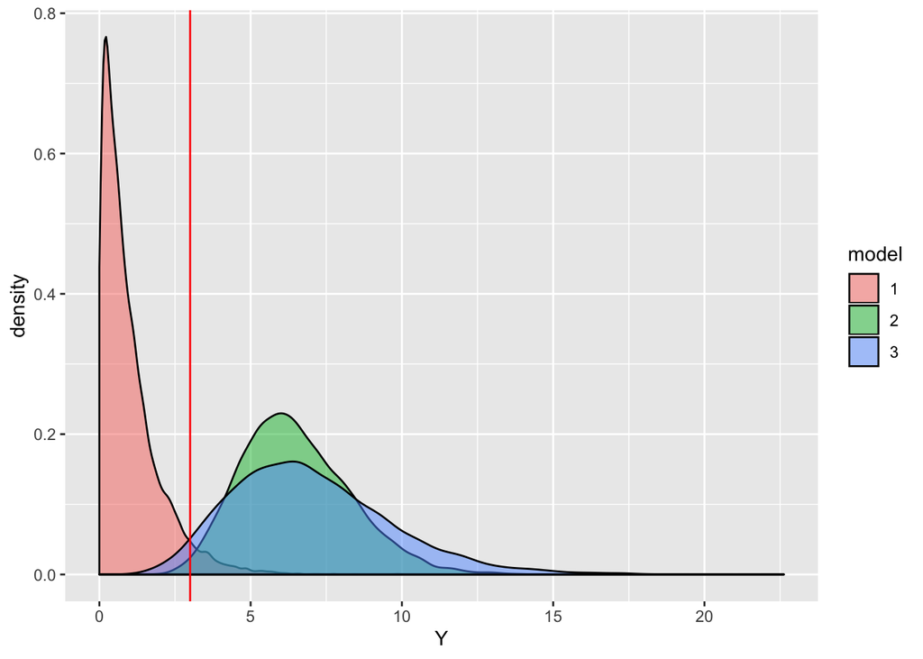

```r
Y_1 <- rgamma(10000, shape = 1, rate =  1)
Y_2 <- rgamma(10000, shape = 13, rate = 2)
Y_3 <- rgamma(10000, shape = 7, rate = 1)
y <- 3

distributions <- data.frame(Y = c(Y_1,Y_2,Y_3), model = rep(c("1","2","3"), each = 10000))

# Plot predictive distributions for y ~ Poisson(\lambda)
distributions %>%
  ggplot() +
  geom_density(mapping = aes(x = Y, fill = model), alpha = 0.5) +
  geom_vline(mapping = aes(xintercept = y), color = "red")
```

## Mean squared error & weighted mean squared error

```r
# MSE for models 1, 2, & 3
(y - mean(Y_1))^2
```

```
## [1] 4.012403
```

```r
(y - mean(Y_2))^2
```

```
## [1] 12.22129
```

```r
(y - mean(Y_3))^2
```

```
## [1] 15.93123
```

```r
# Weighted MSE for models 1, 2, & 3
(y - mean(pred_1))^2 / var(pred_1)
```

```
## [1] 4.516544
```

```r
(y - mean(pred_2))^2 / var(pred_2)
```

```
## [1] 4.94408
```

```r
(y - mean(pred_3))^2 / var(pred_3)
```

```
## [1] 1.337111
```

MSE seems like it doesn’t really make sense in evaluating these models, unless predictions are commonly made on the posterior mean for non-symmetric distributions.

## Median Absolute Deviation with Median as center

```r
# Comparing to median
abs(y - median(Y_1)) / mad(Y_1, constant = 1)
```

```
## [1] 4.826631
```

```r
abs(y - median(Y_2)) / mad(Y_2, constant = 1)
```

```
## [1] 2.770447
```

```r
abs(y - median(Y_3)) / mad(Y_3, constant = 1)
```

```
## [1] 2.170631
```

```r
# Squared = similar to weighted MSE
((y - median(Y_1)) / mad(Y_1, constant = 1))^2
```

```
## [1] 23.29636
```

```r
((y - median(Y_2)) / mad(Y_2, constant = 1))^2
```

```
## [1] 7.675377
```

```r
((y - median(Y_3)) / mad(Y_3, constant = 1))^2
```

```
## [1] 4.71164
```

## Median Absolute Deviation with Mode as center

```r
# Comparing to mode
abs(y - Mode(Y_1)) / mad(Y_1, constant = 1)
```

```
## [1] 5.836277
```

```r
abs(y - Mode(Y_2)) / mad(Y_2, constant = 1)
```

```
## [1] 2.515488
```

```r
abs(y - Mode(Y_3)) / mad(Y_3, constant = 1)
```

```
## [1] 1.989834
```

```r
# Squared = similar to weighted MSE
((y - Mode(Y_1)) / mad(Y_1, constant = 1))^2
```

```
## [1] 34.06213
```

```r
((y - Mode(Y_2)) / mad(Y_2, constant = 1))^2
```

```
## [1] 6.32768
```

```r
((y - Mode(Y_3)) / mad(Y_3, constant = 1))^2
```

```
## [1] 3.959441
```